# hw6_math564

V. V. Dhanvanthar M. [A20543395]

2024-10-10

## Homework 6

## Problem 1

## a

```r
library("ISLR2")
?Carseats
```

```
## starting httpd help server ... done
```

```r
y <- Carseats$Sales
x1 <- ifelse(Carseats$Urban == 'Yes',1,0)
x2 <- ifelse(Carseats$US == 'Yes', 1,0)
x3 <- Carseats$Price

model1 <- lm(y~x1+x2+x3)
summary(model1)
```

```
##
## Call:
## lm(formula = y ~ x1 + x2 + x3)
##
## Residuals:
##     Min      1Q  Median      3Q     Max
## -6.9206 -1.6220 -0.0564  1.5786  7.0581
##
## Coefficients:
##              Estimate Std. Error t value Pr(>|t|)
## (Intercept) 13.043469   0.651012  20.036  < 2e-16 ***
## x1          -0.021916   0.271650  -0.081    0.936
## x2           1.200573   0.259042   4.635 4.86e-06 ***
## x3          -0.054459   0.005242 -10.389  < 2e-16 ***
## ---
## Signif. codes:  0 '***' 0.001 '**' 0.01 '*' 0.05 '.' 0.1 ' ' 1
##
## Residual standard error: 2.472 on 396 degrees of freedom
## Multiple R-squared:  0.2393, Adjusted R-squared:  0.2335
## F-statistic: 41.52 on 3 and 396 DF,  p-value: < 2.2e-16
```

## c

From the summary, we can observe the p values of the three input features. 1. Urban –> p-value = 0.936 >> 0.05. So unable to reject null hypothesis, which means there is no relationship between Urban and sales [Not significant] 2. US –> P-value = 4.86e-06 << 0.05. So, it Rejects null hypothesis [Significant]. 3. Price –> P-value = 2e-16 <<< 0.05. So, it Rejects null hypothesis [Significant].

## d

Since Urban is not significant, in feature selection, i am omitting Urban and considering only US and Price.

```r
y <- Carseats$Sales
x1 <- ifelse(Carseats$US == 'Yes',1,0)
x2 <- Carseats$Price
model2 <- lm(y~x1+x2)
summary(model2)
```

```
##
## Call:
## lm(formula = y ~ x1 + x2)
##
## Residuals:
##     Min      1Q  Median      3Q     Max
## -6.9269 -1.6286 -0.0574  1.5766  7.0515
##
## Coefficients:
##             Estimate Std. Error t value Pr(>|t|)
## (Intercept) 13.03079    0.63098  20.652  < 2e-16 ***
## x1           1.19964    0.25846   4.641 4.71e-06 ***
## x2          -0.05448    0.00523 -10.416  < 2e-16 ***
## ---
## Signif. codes:  0 '***' 0.001 '**' 0.01 '*' 0.05 '.' 0.1 ' ' 1
##
## Residual standard error: 2.469 on 397 degrees of freedom
## Multiple R-squared:  0.2393, Adjusted R-squared:  0.2354
## F-statistic: 62.43 on 2 and 397 DF,  p-value: < 2.2e-16
```

## e

RSE [Model 2] = 2.469 < RSE [Model 1] = 2.472 Adjusted R^2 {Model 2} = 0.2354 > Adjusted R^2 [Model 1] = 0.2335

Model 2 has lesser RSE compared Model 1 and model 2 is able to explain variability of y variable better than model 1 [from adjusted r^2] So model 2 performed better than model 1. Still since the Adjusted R^2 is only 0.2335, it is necessary to inlcude more variables for better model fit.

## Problem 2

```r
library(datasets)
data(swiss)
head(swiss)
```

```
##              Fertility Agriculture Examination Education Catholic
## Courtelary        80.2        17.0          15        12     9.96
## Delemont          83.1        45.1           6         9    84.84
## Franches-Mnt      92.5        39.7           5         5    93.40
## Moutier           85.8        36.5          12         7    33.77
## Neuveville        76.9        43.5          17        15     5.16
## Porrentruy        76.1        35.3           9         7    90.57
##              Infant.Mortality
## Courtelary               22.2
## Delemont                 22.2
## Franches-Mnt             20.2
## Moutier                  20.3
## Neuveville               20.6
## Porrentruy               26.6
```

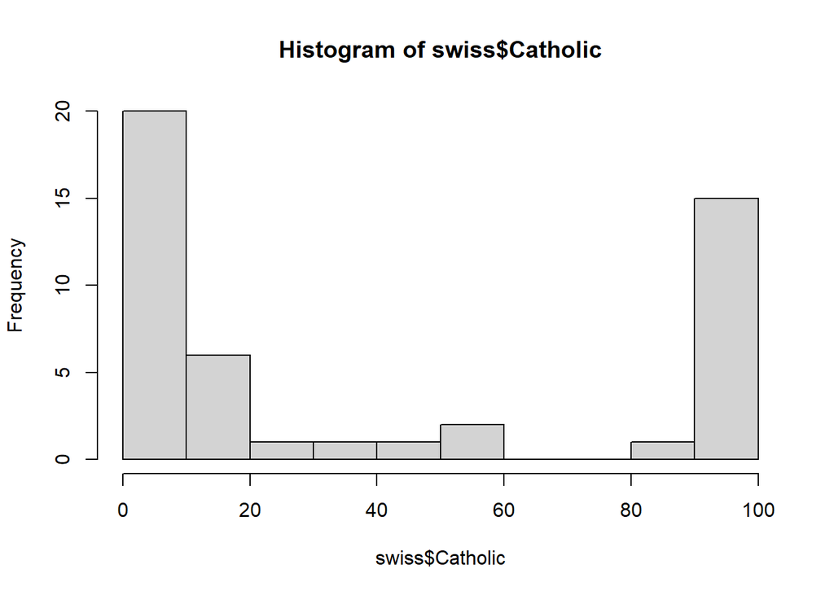

```r
hist(swiss$Catholic)
```

```r
library(dplyr)
#adding a column for 1 or 0 depending on Catholic %
swiss = mutate(swiss, CatholicBin = 1*(Catholic>50))
head(swiss)
```

```
##              Fertility Agriculture Examination Education Catholic
## Courtelary        80.2        17.0          15        12     9.96
## Delemont          83.1        45.1           6         9    84.84
## Franches-Mnt      92.5        39.7           5         5    93.40
## Moutier           85.8        36.5          12         7    33.77
## Neuveville        76.9        43.5          17        15     5.16
## Porrentruy        76.1        35.3           9         7    90.57
##              Infant.Mortality CatholicBin
## Courtelary               22.2           0
## Delemont                 22.2           1
## Franches-Mnt             20.2           1
## Moutier                  20.3           0
## Neuveville               20.6           0
## Porrentruy               26.6           1
```

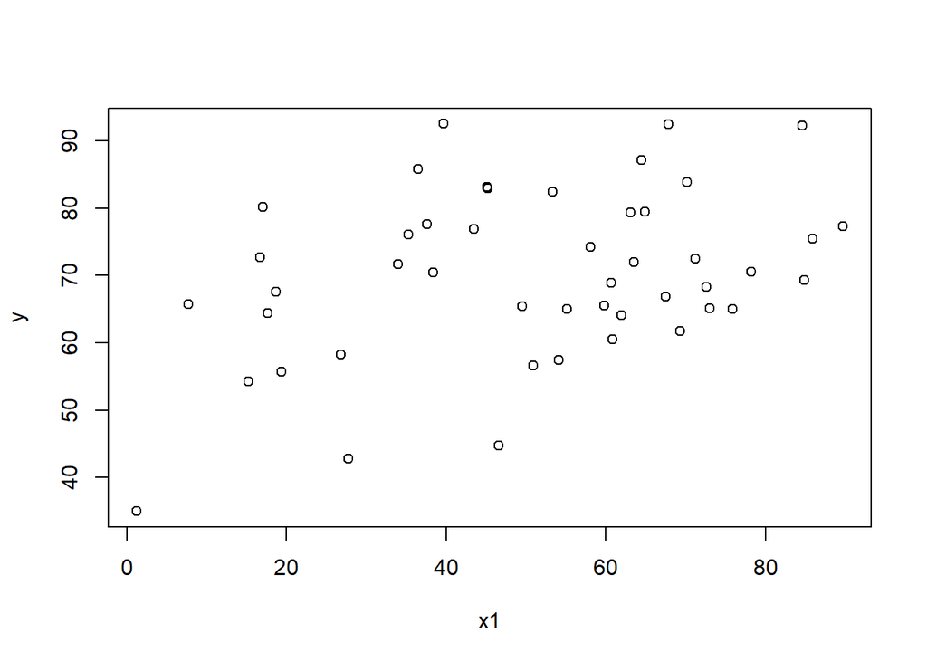

```r
x1 <- swiss$Agriculture
y <- swiss$Fertility
plot(x1,y)
```

```r
model1 <- lm(y ~ x1 + factor(CatholicBin), data=swiss)
summary(model1)$coef
```

```
##                        Estimate Std. Error   t value     Pr(>|t|)
## (Intercept)          60.8322366  4.1058630 14.815944 1.032493e-18
## x1                    0.1241776  0.0810977  1.531210 1.328763e-01
## factor(CatholicBin)1  7.8843292  3.7483622  2.103406 4.118221e-02
```

The coefficient of X2(Catholic) = 7.8843. This means, if we keep x1 constant, the value of Y increase by 7.883 when Catholic is one, else equals to y= beta1*x1 + beta0. Similarly coefficient of X1 0 0.124. Keeping x2 at constant, the value of Y increases by 0.124 when x1 increase by a unit.

## Problem 4

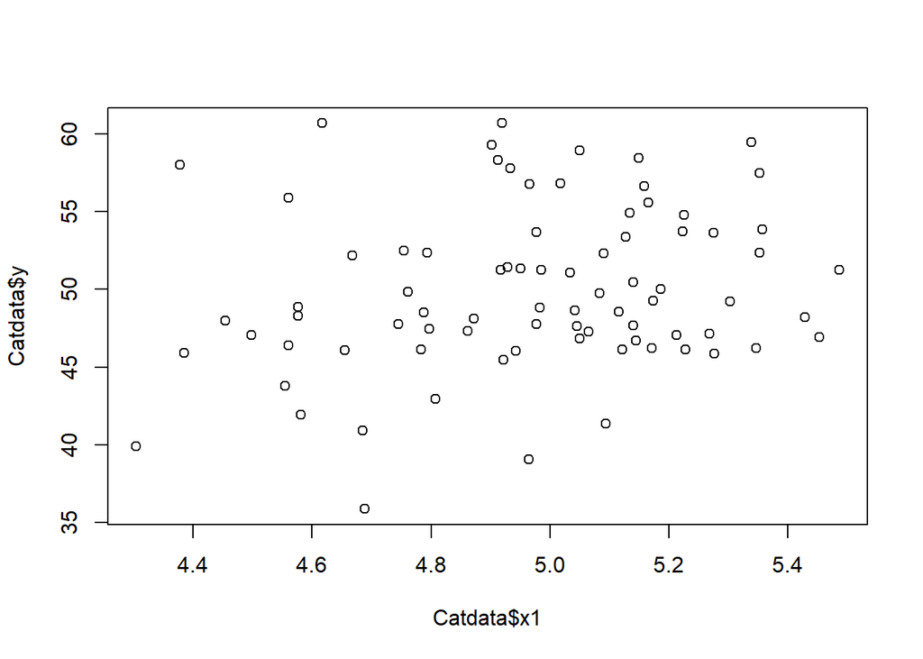

```r
Catdata <- read.csv("D:/3rd_sem/Math564/Cat1.csv", header = TRUE, sep=",")
plot(Catdata$x1, Catdata$y)
```

```r
#create indicator variable
x2 <- ifelse(Catdata$group =="A", 1,0)
x3 <- ifelse(Catdata$group =="B", 1,0)
x4 <- ifelse(Catdata$group =="C", 1,0)
df_new <- data.frame(toolwear = Catdata$y, speed = Catdata$x1, x2, x3, x4)
df_new
```

```
##    toolwear    speed x2 x3 x4
## 1  59.26074 4.902189  1  0  0
## 2  55.55838 5.165739  1  0  0
## 3  47.44312 4.797517  1  0  0
## 4  47.28059 5.064308  1  0  0
## 5  41.35536 5.093231  1  0  0
## 6  52.35375 5.352190  1  0  0
## 7  50.02694 5.185637  1  0  0
## 8  56.74023 4.966180  1  0  0
## 9  53.62048 5.275108  1  0  0
## 10 57.76275 4.933022  1  0  0
## 11 56.62735 5.157934  1  0  0
## 12 49.82867 4.761547  1  0  0
## 13 48.19493 5.428327  1  0  0
## 14 46.39917 4.559954  1  0  0
```

[output cut: 66 more lines]

```r
model1 <- lm(toolwear~speed+factor(x2)+factor(x3)+factor(x4), data=df_new)
summary(model1)
```

```
##
## Call:
## lm(formula = toolwear ~ speed + factor(x2) + factor(x3) + factor(x4),
##     data = df_new)
##
## Residuals:
##      Min       1Q   Median       3Q      Max
## -12.0532  -3.6518  -0.6831   3.6692  13.0063
##
## Coefficients:
##             Estimate Std. Error t value Pr(>|t|)
## (Intercept)   29.730     10.681   2.784   0.0068 **
## speed          3.883      2.134   1.820   0.0728 .
## factor(x2)1    2.113      1.643   1.286   0.2023
## factor(x3)1    1.454      1.643   0.885   0.3792
## factor(x4)1    0.291      1.645   0.177   0.8601
## ---
## Signif. codes:  0 '***' 0.001 '**' 0.01 '*' 0.05 '.' 0.1 ' ' 1
##
## Residual standard error: 5.194 on 75 degrees of freedom
## Multiple R-squared:  0.07094,    Adjusted R-squared:  0.02139
## F-statistic: 1.432 on 4 and 75 DF,  p-value: 0.2318
```

```r
summary(model1)$coef
```

```
##               Estimate Std. Error   t value    Pr(>|t|)
## (Intercept) 29.7302164  10.680868 2.7835020 0.006801382
## speed        3.8833220   2.133754 1.8199486 0.072756899
## factor(x2)1  2.1128304   1.642591 1.2862791 0.202302342
## factor(x3)1  1.4536097   1.643256 0.8845913 0.379204223
## factor(x4)1  0.2910097   1.645463 0.1768558 0.860098372
```

From the coefficients of X2,X3,X4 we can tell: 1.On average there is 2.113, 1.454, 0.291 increase in tool wear for unit increase in A, B, C respectively. 2. This means, Tool A has higher impact individually on tool wear while tool c has the least impact.

Coming to P-values, none of the values are less than (0.05) which indicates none of them are significant and failed to reject null hypothesis.

R-squared (0.07094): This indicates that only 7% of the variability in tool wear is explained by the model (speed and tool model), which suggests that the model does not provide a good fit for the data.